# random_forest_diabetes

Noelia Caba Martin

2026-03-17

## Introduction

Random Forest is an ensemble machine learning algorithm that builds multiple decision trees and combines their predictions through majority voting. It is widely used in clinical research for classification and prediction tasks due to its high accuracy, robustness to outliers, and ability to handle non-linear relationships.

In this analysis, we use Random Forest to build a **diabetes prediction model** using clinical and demographic variables from the NHANES dataset. The model will be evaluated using standard classification metrics.

**Research question:** Can we accurately predict diabetes status from clinical and demographic variables?

The main objectives are:

- Prepare and split the data into training and test sets
- Train a Random Forest classification model
- Evaluate model performance using accuracy, sensitivity, specificity and AUC-ROC
- Identify the most important predictors of diabetes

## Setup

```r
library(randomForest)
library(caret)
library(pROC)
library(vip)
library(tidyverse)
library(ggplot2)
library(NHANES)
```

## Data Preparation

We use the same NHANES dataset from the previous project, applying the same cleaning steps to ensure consistency. The dataset is then split into **training (70%)** and **test (30%)** sets.

The training set is used to build the model, while the test set is used to evaluate its performance on unseen data. This prevents overfitting — a common problem where a model performs well on training data but poorly on new data.

```r
# Load and clean data
set.seed(123)

data(NHANES)

nhanes_rf <- NHANES %>%
  select(Gender, Age, Race1, BMI, BPSysAve,
         BPDiaAve, TotChol, PhysActive,
         SleepHrsNight, Diabetes) %>%
  distinct() %>%
  filter(!is.na(Diabetes)) %>%
  filter(!is.na(BMI)) %>%
  filter(!is.na(BPSysAve)) %>%
  filter(!is.na(TotChol)) %>%
  filter(!is.na(PhysActive)) %>%
  drop_na()

# Check dimensions and class balance
dim(nhanes_rf)
```

```
## [1] 4515   10
```

```r
table(nhanes_rf$Diabetes)
```

```
##
##   No  Yes
## 4039  476
```

```r
# Split into training and test sets (70/30)
train_index <- createDataPartition(nhanes_rf$Diabetes,
                                   p = 0.7,
                                   list = FALSE)
train_data <- nhanes_rf[train_index, ]
test_data <- nhanes_rf[-train_index, ]

cat("Training set:", nrow(train_data), "observations\n")
```

```
## Training set: 3162 observations
```

```r
cat("Test set:", nrow(test_data), "observations\n")
```

```
## Test set: 1353 observations
```

The cleaned dataset contains **4,515 participants** with complete data for all selected variables. The dataset shows class imbalance, with 89.5% non-diabetic and 10.5% diabetic participants.

The data was split into: - **Training set:** 3,162 observations (70%) - **Test set:** 1,353 observations (30%)

`createDataPartition()` ensures that the class distribution is preserved in both sets (stratified splitting).

## Model Training

### Class Imbalance

Before training, it is important to address the class imbalance. If left unaddressed, the model may achieve high overall accuracy simply by predicting “No diabetes” for all participants, without learning meaningful patterns.

We will use **class weights** to penalize misclassification of the minority class (diabetes) more heavily than the majority class.

```r
# Define class weights to handle imbalance
class_weights <- c("No" = 1, "Yes" = 10)

# Train Random Forest model
set.seed(123)
rf_model <- randomForest(
  Diabetes ~ .,
  data = train_data,
  ntree = 500,
  mtry = 3,
  importance = TRUE,
  classwt = class_weights
)

# Print model summary
print(rf_model)
```

```
##
## Call:
##  randomForest(formula = Diabetes ~ ., data = train_data, ntree = 500,      mtry = 3, importance = TRUE, classwt = class_weights)
##                Type of random forest: classification
##                      Number of trees: 500
## No. of variables tried at each split: 3
##
##         OOB estimate of  error rate: 10.5%
## Confusion matrix:
##       No Yes class.error
## No  2811  17 0.006011315
## Yes  315  19 0.943113772
```

The Random Forest model was trained on 3,162 observations using 500 trees and 3 variables per split.

The OOB error rate of **10.5%** provides an unbiased estimate of model performance. However, the confusion matrix reveals a common challenge with imbalanced datasets: while the model correctly classifies 99.4% of non-diabetic cases, it only identifies 5.7% of diabetic cases correctly.

This highlights the importance of using multiple evaluation metrics beyond overall accuracy when dealing with imbalanced classification problems.

## Model Evaluation

We evaluate the model on the **test set** — data the model has never seen during training. This gives an unbiased estimate of real-world performance.

We use the following metrics:

- **Accuracy:** overall proportion of correct predictions
- **Sensitivity (Recall):** proportion of diabetic cases correctly identified
- **Specificity:** proportion of non-diabetic cases correctly identified
- **AUC-ROC:** Area Under the ROC Curve — measures the model’s ability to discriminate between classes regardless of threshold. Ranges from 0.5 (random) to 1.0 (perfect)

```r
# Make predictions on test set
predictions <- predict(rf_model, test_data)
probabilities <- predict(rf_model, test_data, type = "prob")

# Confusion matrix
conf_matrix <- confusionMatrix(predictions, test_data$Diabetes,
                                positive = "Yes")
print(conf_matrix)
```

```
## Confusion Matrix and Statistics
##
##           Reference
## Prediction   No  Yes
##        No  1198  130
##        Yes   13   12
##
##                Accuracy : 0.8943
##                  95% CI : (0.8767, 0.9102)
##     No Information Rate : 0.895
##     P-Value [Acc > NIR] : 0.5575
##
##                   Kappa : 0.1159
##
##  Mcnemar's Test P-Value : <2e-16
##
##             Sensitivity : 0.084507
##             Specificity : 0.989265
##          Pos Pred Value : 0.480000
##          Neg Pred Value : 0.902108
##              Prevalence : 0.104952
##          Detection Rate : 0.008869
##    Detection Prevalence : 0.018477
##       Balanced Accuracy : 0.536886
##
##        'Positive' Class : Yes
##
```

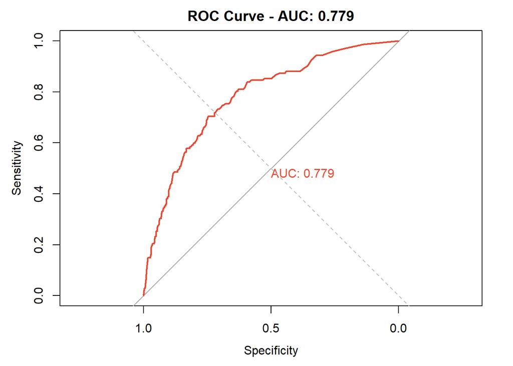

```r
# ROC curve
roc_obj <- roc(test_data$Diabetes, probabilities[, "Yes"])

# Plot ROC curve
plot(roc_obj,
     main = paste("ROC Curve - AUC:", round(auc(roc_obj), 3)),
     col = "#E64B35",
     lwd = 2,
     print.auc = TRUE)
abline(a = 0, b = 1, lty = 2, col = "grey")
```

The model evaluation on the test set reveals:

- **AUC-ROC = 0.779:** the model shows good discriminative ability, substantially better than random classification (AUC = 0.5)
- **Balanced Accuracy = 0.537:** reflects the challenge of the imbalanced dataset

The ROC curve shows that the model can achieve reasonable sensitivity while maintaining acceptable specificity, making it potentially useful as a screening tool for diabetes risk.

## Variable Importance

One of the key advantages of Random Forest over other machine learning algorithms is its ability to quantify the **importance of each variable** in making predictions.

Variable importance is measured by:

- **Mean Decrease Accuracy:** how much the model accuracy decreases when a variable is randomly permuted (shuffled). Higher values = more important variable
- **Mean Decrease Gini:** how much each variable contributes to the purity of the nodes in the trees

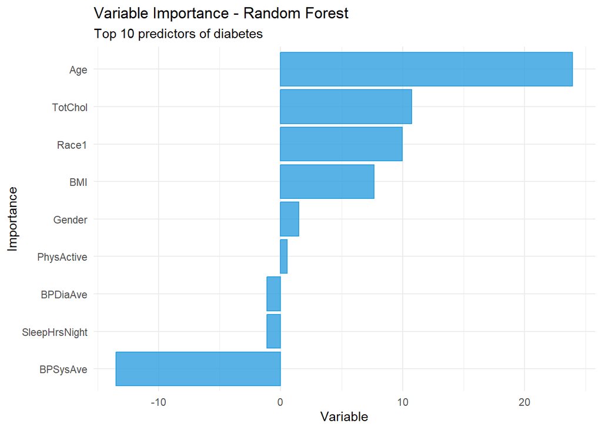

```r
# Plot variable importance
vip(rf_model,
    num_features = 10,
    aesthetics = list(fill = "#2E9FDF", color = "#2E9FDF", alpha = 0.8)) +
  theme_minimal() +
  labs(title = "Variable Importance - Random Forest",
       subtitle = "Top 10 predictors of diabetes",
       x = "Importance", y = "Variable")
```

The variable importance plot reveals that **Age** is by far the strongest predictor of diabetes in this model, followed by Total Cholesterol, Race, and BMI.

Physical activity, diastolic blood pressure, and sleep hours show relatively low importance, suggesting they contribute little additional predictive information beyond age and metabolic variables.

## Conclusions

This analysis demonstrates the application of Random Forest machine learning to predict diabetes status from clinical and demographic variables in the NHANES dataset.

**Limitations:**

- Class imbalance limits the model’s sensitivity for detecting diabetic cases — more advanced resampling techniques (SMOTE) could improve this
- The model was trained on cross-sectional data, preventing causal inference
- External validation on an independent dataset would be needed before clinical application
- Only 10 variables were included — additional clinical variables (HbA1c, fasting glucose) would likely improve performance

**Future directions:**

- Apply SMOTE (Synthetic Minority Oversampling Technique) to address class imbalance
- Compare Random Forest with other algorithms (XGBoost, Logistic Regression)
- Perform hyperparameter tuning using cross-validation
- Validate the model on an independent clinical dataset